# Project2: Investigate a Dataset (IMDb Movie Database)

- Introduction
- Data Wrangling
- Exploratory Data Analysis
- Conclusions

## Introduction

> The Movie Database (TMDb) contains info on 10,000 movies. The dataset size makes it for a very good introductory example for the Nanodegree.

> Some of the high level questions that I'll try to answer are:
> - what properties make movies popular?
> - what properties make movies profitable?
> - what are some of the trends thru the years?
> - what are some of the top10 characteristics of movies?

> I start by loading some basic libraries into the IPYNB:

```python
import matplotlib.pyplot as plt
import numpy as np
import os
import pandas as pd
%matplotlib inline

os.getcwd()
```

```
'C:\\wp3830gpu\\notebooks'
```

## Data Wrangling

> Certain columns, like ‘cast’ and ‘genres’, contain multiple values separated by pipe (|) characters.

> There are some odd charactersin the ‘cast’ column. Don’t worry about cleaning them. You can leave them as is.

> The final two columns ending with “_adj” show the budget and revenue of the associated movie in terms of 2010 dollars, accounting for inflation

### Load data and inspect

```python
df_all = pd.read_csv('tmdb-movies.csv')

# 1a - discover
df_all.info()
print()
df_all.head(2)
print()
df_all.describe()
```

```
<class 'pandas.core.frame.DataFrame'>
RangeIndex: 10866 entries, 0 to 10865
Data columns (total 21 columns):
 #   Column                Non-Null Count  Dtype
---  ------                --------------  -----
 0   id                    10866 non-null  int64
 1   imdb_id               10856 non-null  object
 2   popularity            10866 non-null  float64
 3   budget                10866 non-null  int64
 4   revenue               10866 non-null  int64
 5   original_title        10866 non-null  object
 6   cast                  10790 non-null  object
 7   homepage              2936 non-null   object
 8   director              10822 non-null  object
 9   tagline               8042 non-null   object
 10  keywords              9373 non-null   object
 11  overview              10862 non-null  object
 12  runtime               10866 non-null  int64
 13  genres                10843 non-null  object
 14  production_companies  9836 non-null   object
 15  release_date          10866 non-null  object
 16  vote_count            10866 non-null  int64
 17  vote_average          10866 non-null  float64
 18  release_year          10866 non-null  int64
 19  budget_adj            10866 non-null  float64
 20  revenue_adj           10866 non-null  float64
dtypes: float64(4), int64(6), object(11)
memory usage: 1.7+ MB
```

|  | id | popularity | budget | revenue | runtime | vote_count | vote_average | release_year | budget_adj | revenue_adj |
| --- | --- | --- | --- | --- | --- | --- | --- | --- | --- | --- |
| count | 10866.000000 | 10866.000000 | 1.086600e+04 | 1.086600e+04 | 10866.000000 | 10866.000000 | 10866.000000 | 10866.000000 | 1.086600e+04 | 1.086600e+04 |
| mean | 66064.177434 | 0.646441 | 1.462570e+07 | 3.982332e+07 | 102.070863 | 217.389748 | 5.974922 | 2001.322658 | 1.755104e+07 | 5.136436e+07 |
| std | 92130.136561 | 1.000185 | 3.091321e+07 | 1.170035e+08 | 31.381405 | 575.619058 | 0.935142 | 12.812941 | 3.430616e+07 | 1.446325e+08 |
| min | 5.000000 | 0.000065 | 0.000000e+00 | 0.000000e+00 | 0.000000 | 10.000000 | 1.500000 | 1960.000000 | 0.000000e+00 | 0.000000e+00 |
| 25% | 10596.250000 | 0.207583 | 0.000000e+00 | 0.000000e+00 | 90.000000 | 17.000000 | 5.400000 | 1995.000000 | 0.000000e+00 | 0.000000e+00 |
| 50% | 20669.000000 | 0.383856 | 0.000000e+00 | 0.000000e+00 | 99.000000 | 38.000000 | 6.000000 | 2006.000000 | 0.000000e+00 | 0.000000e+00 |
| 75% | 75610.000000 | 0.713817 | 1.500000e+07 | 2.400000e+07 | 111.000000 | 145.750000 | 6.600000 | 2011.000000 | 2.085325e+07 | 3.369710e+07 |
| max | 417859.000000 | 32.985763 | 4.250000e+08 | 2.781506e+09 | 900.000000 | 9767.000000 | 9.200000 | 2015.000000 | 4.250000e+08 | 2.827124e+09 |

### Data Cleaning

> remove columns that are not necessary

```python
# remove columns that are not necessary
cols_not_needed = ['budget', 'homepage', 'overview', 'revenue', 'tagline']
df_all.drop(cols_not_needed, axis=1, inplace=True)
```

### Data Cleaning

> find duplicates and drop them

```python
# find duplicates and drop them
print('duplicates=', df_all.duplicated().value_counts())
df_all.drop_duplicates(keep = 'first', inplace = True)
```

```
duplicates= False    10865
True         1
dtype: int64
```

### Data Cleaning

> check for nulls

```python
# check for nulls
df_all.isna().sum()
```

```
id                         0
imdb_id                   10
popularity                 0
original_title             0
cast                      76
director                  44
keywords                1493
runtime                    0
genres                    23
production_companies    1030
release_date               0
vote_count                 0
vote_average               0
release_year               0
budget_adj                 0
revenue_adj                0
dtype: int64
```

### Data Cleaning

> there are 0s in budget and revenue, drop those entries

```python
# there are 0s in budget and revenue, drop those entries
df = df_all
df = df[df['budget_adj']  !=0]
df = df[df['revenue_adj'] !=0]
```

### Data Cleaning

> view dtypes

```python
print(df.dtypes)
```

```
id                        int64
imdb_id                  object
popularity              float64
original_title           object
cast                     object
director                 object
keywords                 object
runtime                   int64
genres                   object
production_companies     object
release_date             object
vote_count                int64
vote_average            float64
release_year              int64
budget_adj              float64
revenue_adj             float64
dtype: object
```

### Data Cleaning

> fix release_date dtype

```python
# fix release_date dtype
df['release_date'] = pd.to_datetime(df['release_date'])
print(df.dtypes)
```

```
id                               int64
imdb_id                         object
popularity                     float64
original_title                  object
cast                            object
director                        object
keywords                        object
runtime                          int64
genres                          object
production_companies            object
release_date            datetime64[ns]
vote_count                       int64
vote_average                   float64
release_year                     int64
budget_adj                     float64
revenue_adj                    float64
dtype: object
```

## Exploratory Data Analysis

### Create new columns: PROFIT and NPMR

> Needed since profit was not part of the original dataset

```python
# insert new cols : profit and net profit margin ratio (NPMR)
df.insert(df.shape[1], 'profit_adj', df['revenue_adj'] - df['budget_adj'])
df.insert(df.shape[1], 'npmr', df['profit_adj'] / df['budget_adj'] * 100)
```

### Research Question 1 - Which year has the highest release of movies?

```
the highest movie releases happened in : 2011
```

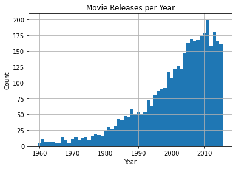

```python
# Q. Which year has the highest release of movies?

movies_per_year = df['release_year'].value_counts()
print('the highest movie releases happened in :', movies_per_year.idxmax())

plt.figure() # Numpy Style (More control over bins)
binwidth = 1
bin_min = df['release_year'].min() - 0.5
bin_max = df['release_year'].max() + 0.5 + 1.0
bins = np.arange(bin_min, bin_max, 1.0)
plt.hist( df['release_year'].astype(float), bins=bins)
plt.title('Movie Releases per Year')
plt.xlabel('Year')
plt.ylabel('Count')
plt.grid(True)
```

There seems to be a trend of the most movie releases happening in the last 10 years

### Research Question 2 - How has movie revenue changed thru the years?

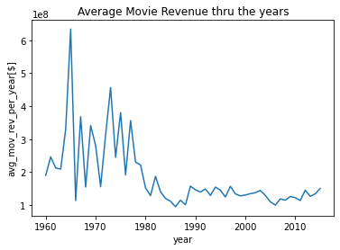

```python
# Q. How has movie revenue changed thru the years?
rev_tot_per_year = df.groupby('release_year')['revenue_adj'].sum()
movies_per_year  = df.groupby('release_year')['release_year'].count()
avg_mov_rev_per_year = rev_tot_per_year / movies_per_year
plt.figure()
plt.plot(avg_mov_rev_per_year)
plt.title('Average Movie Revenue thru the years')
plt.xlabel('year')
plt.ylabel('avg_mov_rev_per_year[$]')
```

The data shows a higher average movie revenue during the 60s and 70s. Not sure if it is true or there is not enough data about low revenue movies during those years that did not make it into the IMDb.

### Research Question 3 - What is mean and the distribution for movie revenue?

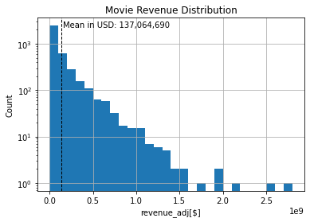

```python
# Q. What is the distribution of revenue?

plt.figure()
binwidth = 1
bin_min = df['revenue_adj'].min() - 0.5
bin_max = df['revenue_adj'].max() + 0.5 + 1.0
bins = np.arange(bin_min, bin_max, 100000000.0)
plt.hist( df['revenue_adj'].astype(float), bins=bins)
plt.axvline(df['revenue_adj'].mean(), color='k', linestyle='dashed', linewidth=1)
min_ylim, max_ylim = plt.ylim()
plt.text(df['revenue_adj'].mean()*1.1, max_ylim*0.9, 'Mean in USD: {:,.0f}'.format(df['revenue_adj'].mean()))
plt.yscale('log')
plt.title('Movie Revenue Distribution')
plt.xlabel('revenue_adj[$]')
plt.ylabel('Count')
plt.grid(True)
```

### Research Question 4 - What is the mean and distribution for movie profit?

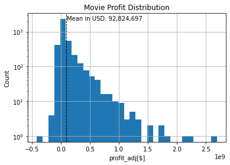

```python
# Q. What is the distribution of profit?

plt.figure()
binwidth = 1
bin_min = df['profit_adj'].min() - 0.5
bin_max = df['profit_adj'].max() + 0.5 + 1.0
bins = np.arange(bin_min, bin_max, 100000000.0)
plt.hist( df['profit_adj'].astype(float), bins=bins)
plt.axvline(df['profit_adj'].mean(), color='k', linestyle='dashed', linewidth=1)
min_ylim, max_ylim = plt.ylim()
plt.text(df['profit_adj'].mean()*1.1, max_ylim*0.9, 'Mean in USD: {:,.0f}'.format(df['profit_adj'].mean()))
plt.yscale('log')
plt.title('Movie Profit Distribution')
plt.xlabel('profit_adj[$]')
plt.ylabel('Count')
plt.grid(True)
```

### Research Question 5 - What is the Average Runtime Of Movies From Year To Year?

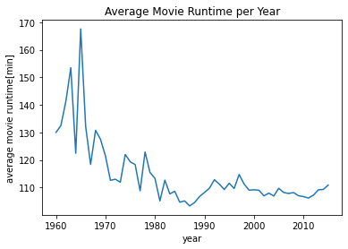

```python
# Q. MOVIE RUNTIME - Average Runtime Of Movies From Year To Year?
rt_tot_per_year = df.groupby('release_year')['runtime'].sum()
movies_per_year = df.groupby('release_year')['release_year'].count()
avg_rt_per_year = rt_tot_per_year / movies_per_year
plt.figure()
plt.plot(avg_rt_per_year)
plt.title('Average Movie Runtime per Year')
plt.xlabel('year')
plt.ylabel('average movie runtime[min]')
```

The average movie runtime has decreased in time, flattening out after the 80s.

### Research Question 6 - What is the Runtime distribution?

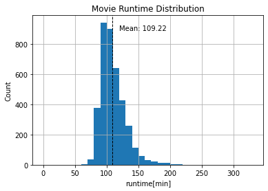

```python
# Q. MOVIE RUNTIME - Runtime distribution?
plt.figure()
binwidth = 1
bin_min = 0
bin_max = round(df['runtime'].max()/10) * 10
bins = np.arange(bin_min, bin_max, 10.0)
plt.hist( df['runtime'].astype(float), bins=bins)
plt.axvline(df['runtime'].mean(), color='k', linestyle='dashed', linewidth=1)
min_ylim, max_ylim = plt.ylim()
plt.text(df['runtime'].mean()*1.1, max_ylim*0.9, 'Mean: {:.2f}'.format(df['runtime'].mean()))
plt.title('Movie Runtime Distribution')
plt.xlabel('runtime[min]')
plt.ylabel('Count')
plt.grid(True)
```

### Research Question 7 - Are there any runtime outliers?

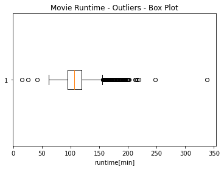

```python
# Q. MOVIE RUNTIME - Runtime distribution- Outliers?
plt.figure()
plt.boxplot(df['runtime'], vert=False)
plt.title('Movie Runtime - Outliers - Box Plot')
plt.xlabel('runtime[min]')
```

> The Box plot shows quite a bit of outliers for the runtime category, that would explain the highest runtime movie, which was actually a TV series.

```
the highest movie releases = 460 , happens in month = 9
```

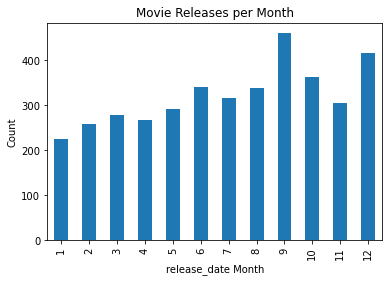

```python
# Q. RELATIONSHIPS - Revenue Vs. Release Month
movies_by_month_number = df.groupby(df['release_date'].dt.month).count()['imdb_id']
movies_by_month_number.rename_axis('month', inplace=True)
movies_by_month_name   = df.groupby(df['release_date'].dt.month_name()).count()['imdb_id']
movies_by_month_name.rename_axis('month', inplace=True)

print('the highest movie releases =', movies_by_month_number.max(), ', happens in month =', movies_by_month_number.idxmax())

plt.figure()
movies_by_month_number.plot(kind='bar')
plt.title('Movie Releases per Month')
plt.xlabel('release_date Month')
plt.ylabel('Count')
```

Most movies are released in September (after schools starts again in the fall) and December (during holidays).

### Research Question 9 - What kinds of properties are associated with movies that have high revenues?

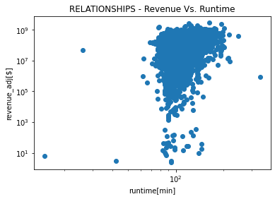

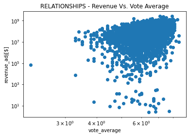

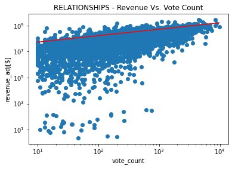

```python
# RELATIONSHIPS - Revenue Vs. Runtime
plt.figure()
plt.scatter(df['runtime'], df['revenue_adj'])
plt.xscale('log')
plt.yscale('log')
plt.xlabel('runtime[min]')
plt.ylabel('revenue_adj[$]')
plt.title('RELATIONSHIPS - Revenue Vs. Runtime')

# RELATIONSHIPS - Revenue Vs. Vote Average
plt.figure()
plt.scatter(df['vote_average'], df['revenue_adj'])
plt.xscale('log')
plt.yscale('log')
plt.xlabel('vote_average')
plt.ylabel('revenue_adj[$]')
plt.title('RELATIONSHIPS - Revenue Vs. Vote Average')

# RELATIONSHIPS - Revenue Vs. Vote Count
plt.figure()
plt.scatter(df['vote_count'], df['revenue_adj'])
plt.xscale('log')
plt.yscale('log')
plt.xlabel('vote_count')
plt.ylabel('revenue_adj[$]')
plt.title('RELATIONSHIPS - Revenue Vs. Vote Count')
# trend
fit = np.polyfit(df['vote_count'], df['revenue_adj'], 1)
fit_fn = np.poly1d(fit)
x = [df['vote_count'].min(), df['vote_count'].max()]
y = [fit_fn(df['vote_count'].min()), fit_fn(df['vote_count'].max())]
plt.plot(x,y, color='red')
```

> Log-Log plots were used to improve readability of charts There seems to be a good correlation of vote_count to revenue

### Research Question 10 - TOP10 Popular, # Votes, and Vote Average Movies

```
([0, 1, 2, 3, 4, 5, 6, 7, 8, 9], <a list of 10 Text major ticklabel objects>)
```

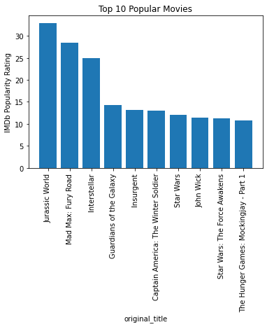

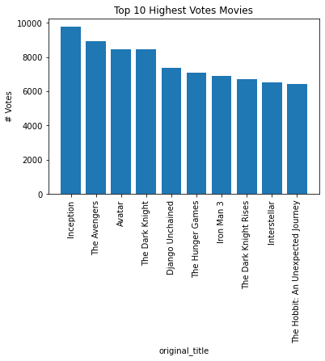

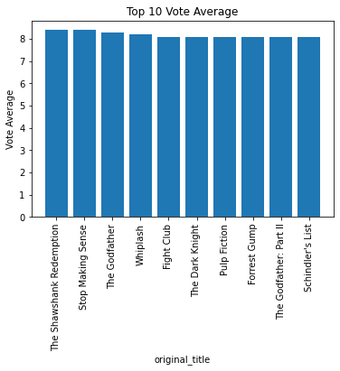

```python
# Q.
# Top 10 - Popularity
# Top 10 - number of votes movies
# Top 10 - vote average

popularity_top10   = df.nlargest(10, 'popularity',   keep='first')
vote_count_top10   = df.nlargest(10, 'vote_count',   keep='first')
vote_average_top10 = df.nlargest(10, 'vote_average', keep='first')

plt.figure()
plt.bar(popularity_top10['original_title'], popularity_top10['popularity'])
plt.title('Top 10 Popular Movies')
plt.xlabel('original_title')
plt.ylabel('IMDb Popularity Rating')
plt.xticks(rotation='vertical')

plt.figure()
plt.bar(vote_count_top10['original_title'], vote_count_top10['vote_count'])
plt.title('Top 10 Highest Votes Movies')
plt.xlabel('original_title')
plt.ylabel('# Votes')
plt.xticks(rotation='vertical')

plt.figure()
plt.bar(vote_average_top10['original_title'], vote_average_top10['vote_average'])
plt.title('Top 10 Vote Average')
plt.xlabel('original_title')
plt.ylabel('Vote Average')
plt.xticks(rotation='vertical')
```

The top10 most popular, highest vote count and highest vote average are not the same.

### Research Question 11 - TOP 10 Short/Long Runtime, Lo/Hi Budgets, Lo/Hi Revenues

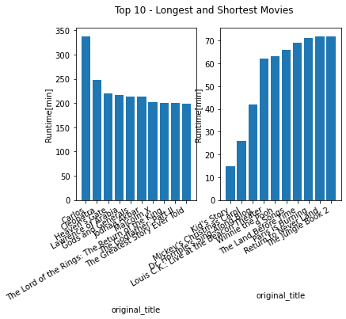

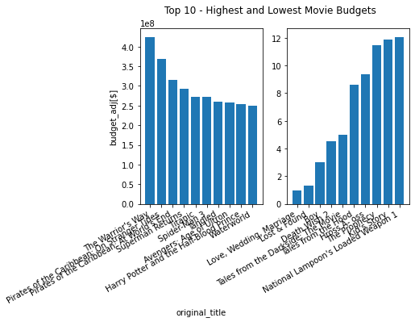

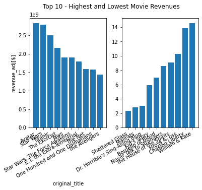

```python
# Q.
# Top 10 shortest/longest runtime movies
# Top 10 lo/hi movie budgets
# Top 10 lo/hi movie revenues

longest_top10    = df.nlargest(10,  'runtime',   keep='first')
short_top10      = df.nsmallest(10, 'runtime',   keep='first')
budget_hi_top10  = df.nlargest(10,  'budget_adj', keep='first')
budget_lo_top10  = df.nsmallest(10, 'budget_adj', keep='first')
revenue_hi_top10 = df.nlargest(10,  'revenue_adj', keep='first')
revenue_lo_top10 = df.nsmallest(10, 'revenue_adj', keep='first')
# lo/hi movie revenue index (for reference)
revenue_lo_ix = df['revenue_adj'].idxmin()
revenue_hi_ix = df['revenue_adj'].idxmax()

fig, ax = plt.subplots(nrows=1, ncols=2)
ax[0].bar(longest_top10['original_title'], longest_top10['runtime'])
ax[0].set_xlabel('original_title')
ax[0].set_ylabel('Runtime[min]')
ax[1].bar(short_top10['original_title'], short_top10['runtime'])
ax[1].set_xlabel('original_title')
ax[1].set_ylabel('Runtime[min]')
plt.draw() # needed to get the movie titles aligned correctly
ax[0].set_xticklabels(ax[0].get_xticklabels(), rotation=30, ha='right')
ax[1].set_xticklabels(ax[1].get_xticklabels(), rotation=30, ha='right')
fig.suptitle('Top 10 - Longest and Shortest Movies')

fig, ax = plt.subplots(nrows=1, ncols=2)
ax[0].bar(budget_hi_top10['original_title'], budget_hi_top10['budget_adj'])
ax[0].set_xlabel('original_title')
ax[0].set_ylabel('budget_adj[$]')
ax[1].bar(budget_lo_top10['original_title'], budget_lo_top10['budget_adj'])
ax[0].set_ylabel('budget_adj[$]')
plt.draw() # needed to get the movie titles aligned correctly
ax[0].set_xticklabels(ax[0].get_xticklabels(), rotation=30, ha='right')
ax[1].set_xticklabels(ax[1].get_xticklabels(), rotation=30, ha='right')
fig.suptitle('Top 10 - Highest and Lowest Movie Budgets')

fig, ax = plt.subplots(nrows=1, ncols=2)
ax[0].bar(revenue_hi_top10['original_title'], revenue_hi_top10['revenue_adj'])
ax[0].set_xlabel('original_title')
ax[0].set_ylabel('revenue_adj[$]')
ax[1].bar(revenue_lo_top10['original_title'], revenue_lo_top10['revenue_adj'])
ax[0].set_ylabel('revenue_adj[$]')
plt.draw() # needed to get the movie titles aligned correctly
ax[0].set_xticklabels(ax[0].get_xticklabels(), rotation=30, ha='right')
ax[1].set_xticklabels(ax[1].get_xticklabels(), rotation=30, ha='right')
fig.suptitle('Top 10 - Highest and Lowest Movie Revenues')
```

There is a wide range of runtime, budget and revenue for movies. This makes sense since some of them are mega productions and some other are independent film productions.

### Research Question 12 - TOP 10 : Stars, Directors, Genres, Keywords, Production Companies

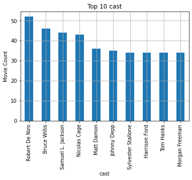

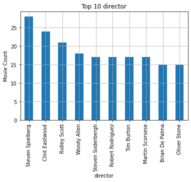

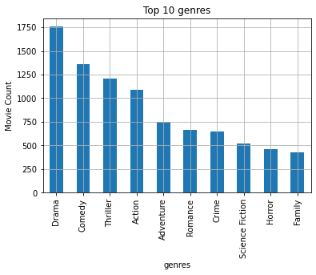

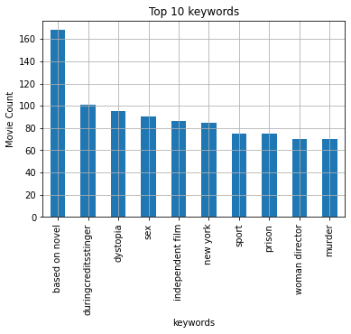

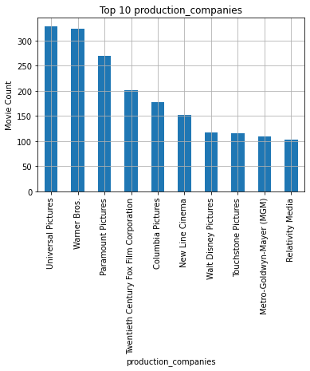

```python
# Q.
# Top 10 Most Frequent star cast?
# Top 10 Most Frequent Directors?
# Top 10 Most Popular Genres?
# Top 10 Most popular keywords?
# Top 10 Most popular Production Companies?

# Wrangling - Certain columns,contain multiple values separated by pipe (|) characters.

def df_string_separate_count(df_col):
    df_col_all     = df_col.str.cat(sep = '|')
    df_col_series  = pd.Series(df_col_all.split('|'))
    df_col_count   = df_col_series.value_counts(ascending = False)
    return df_col_count

prop1 = ['cast', 'director', 'genres', 'keywords', 'production_companies']
prop1_count = []

for i in range(len(prop1)):
    df_prop = df[prop1[i]]
    prop1_count.append(df_string_separate_count(df_prop))

genre_count = prop1_count[2]

for i in range(len(prop1)):
    plt.figure()
    prop1_count[i][0:10].plot(kind='bar')
    plt.xlabel(prop1[i])
    plt.ylabel('Movie Count')
    plt.title('Top 10 ' + prop1[i])
    plt.grid(True)
```

Some actors have a high number of movies such as Robert deNiro and Bruce Willis. Same is true for directors such as Steven Spielberg. Drama has by far the highest movie count. Universal and Warner dominate the movie production.

### Research Question 13 - Which genres are most popular from year to year?

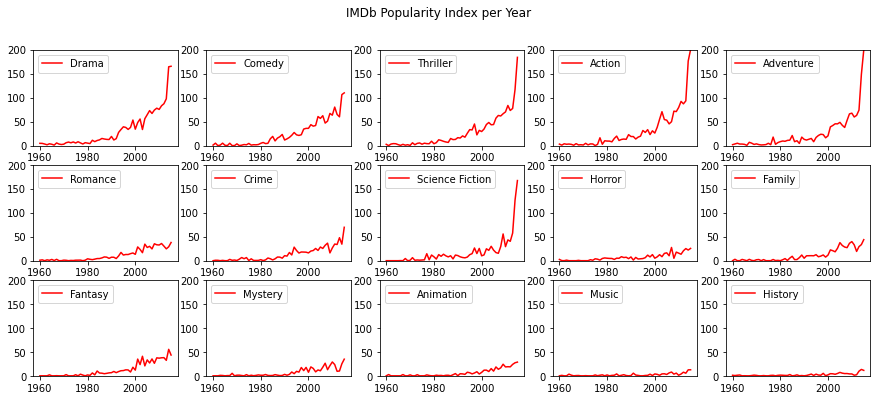

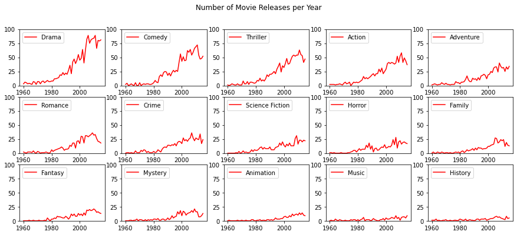

```python
# Q. Which genres are most popular from year to year?

# ordered list of genres
genre = genre_count.index.to_list()
# list of all genres per movie
movie_genres = list(map(str, (df['genres'])))
# year column per movie
year_vector = np.array(df['release_year'])
# IMDb pop per movie
pop_vector  = np.array(df['popularity'])

# empty DF = genre X year(s)
pop_year_df = pd.DataFrame(0.0, index=genre, columns=range(1960, 2016))
cou_year_df = pd.DataFrame(0.0, index=genre, columns=range(1960, 2016))
# fill DF columns with movie popularity
j = 0
for i in movie_genres:
    # for every movie, split genre string into a LIST of multiple movies
    movie_genres_split = list(map(str,i.split('|')))
    # populate DF by adding the IMDb popularity (or a 1.0 count) to that particular genre and year
    pop_year_df.loc[movie_genres_split, year_vector[j]] = pop_year_df.loc[movie_genres_split, year_vector[j]] + pop_vector[j]
    cou_year_df.loc[movie_genres_split, year_vector[j]] = cou_year_df.loc[movie_genres_split, year_vector[j]] + 1.0
    j = j + 1

fig, ax = plt.subplots(nrows=3, ncols=5, figsize=(15,6))
fig.suptitle('IMDb Popularity Index per Year')
k = 0
for i in range(3):
    for j in range(5):
        pop_year_df.loc[genre[k]].plot(label=genre[k], color='red', ax=ax[i][j], legend=True)
        ax[i][j].set_ylim(0, 200)
        ax[i][j].legend(fontsize=10, loc='upper left')
        k = k + 1

fig, ax = plt.subplots(nrows=3, ncols=5, figsize=(15,6))
fig.suptitle('Number of Movie Releases per Year')
k = 0
for i in range(3):
    for j in range(5):
        cou_year_df.loc[genre[k]].plot(label=genre[k], color='red', ax=ax[i][j], legend=True)
        ax[i][j].set_ylim(0, 100)
        ax[i][j].legend(fontsize=10, loc='upper left')
        k = k + 1
```